# Penalised Logistic Tree Regression (PLTR) for Credit Scoring

Abdullah Shahzad

2026-07-09

# Project Overview

This project implements a Penalised Logistic Tree Regression (PLTR) model for corporate credit scoring. Standard logistic regression models often fail to capture non linear “cliffs” in corporate distress, while powerful machine learning models like Random Forests act as uninterpretable black boxes.

The PLTR methodology solves this trade off by using short depth decision trees to automatically detect extreme risk thresholds, and then applying an Adaptive Lasso penalty to filter out the noise. The result is a highly accurate, fully auditable risk scorecard.

# Load Libraries

```r
# Load Required Libraries
library(dplyr)
library(rpart)
library(rpart.plot)
library(glmnet)
library(pROC)
library(ggplot2)
library(randomForest)
```

# Data Sourcing & Feature Engineering

We utilize a dataset of European non financial corporations sourced from Refinitiv Workspace. We exclude financial firms and shell companies because their naturally high leverage and distinct capital structures would distort traditional risk metrics.

Instead of feeding raw accounting data to the algorithm, we engineer the five classic Altman Z Score economic pillars to prevent the model from finding spurious correlations.

```r
# Load Data
df <- read.csv("combined_data.csv")

clean_names <- c("Ticker", "Name", "Country", "MarketCap", "TotalAssets",
                 "RetainedEarnings", "EBIT", "TotalLiabilities", "Revenue",
                 "WorkingCapital", "StatusCode", "Sector", "DelistedFlag",
                 "Rating", "StarMinePD", "Region")
colnames(df) <- clean_names

# Create target binary variable (Default)
df$Default <- ifelse(df$DelistedFlag == TRUE, 1, 0)

# Engineer Structural Economic Pillars (Altman Ratios)
df <- df %>%
  mutate(
    Liquidity = WorkingCapital / TotalAssets,
    RetainedEarningsRatio = RetainedEarnings / TotalAssets,
    EBITRatio = EBIT / TotalAssets,
    MarketLeverage = MarketCap / TotalLiabilities,
    AssetTurnover = Revenue / TotalAssets
  )

# Subset and clean NA/Infinite values
base_vars <- c("Liquidity", "RetainedEarningsRatio", "EBITRatio", "MarketLeverage", "AssetTurnover")
df_clean <- df %>% select(Default, all_of(base_vars)) %>% na.omit()
df_clean <- df_clean[is.finite(rowSums(df_clean[, base_vars])), ]

# Check class imbalance
table(df_clean$Default)
```

```
##
##    0    1
## 5176  133
```

# Step 1: Automated Threshold Detection (Scout Trees)

Corporate default does not happen on a smooth linear scale. Companies can survive declining health until interacting metrics break simultaneously (a “default cliff”).

To detect these cliffs, we deploy 1 split and 2 split decision trees across our five base variables. Every terminal leaf node from these trees is extracted as a binary “Yes/No” rule.

```r
rule_matrix_list <- list()

# Extract Univariate Rules (1-split)
for (var in base_vars) {
  form <- reformulate(termlabels = var, response = "Default")
  uni_var_model <- rpart(formula = form, data = df_clean,
                         control = rpart.control(maxdepth = 1, cp = -1, minsplit = 2))

  leaf_nodes <- as.factor(uni_var_model$where)
  if (length(levels(leaf_nodes)) > 1) {
    dummies <- model.matrix(~ leaf_nodes - 1)
    colnames(dummies) <- paste0(var, "_Node", colnames(dummies))
    rule_matrix_list[[var]] <- dummies
  }
}

# Extract Bivariate Rules (2-split)
for (i in 1:(length(base_vars) - 1)) {
  for (j in (i + 1):length(base_vars)) {
    var1 <- base_vars[i]
    var2 <- base_vars[j]
    pair_name <- paste(var1, var2, sep = "_")

    form <- reformulate(termlabels = c(var1, var2), response = "Default")
    bi_var_model <- rpart(formula = form, data = df_clean,
                          control = rpart.control(maxdepth = 2, cp = -1, minsplit = 2))

    leaf_nodes <- as.factor(bi_var_model$where)
    if (length(levels(leaf_nodes)) > 1) {
      dummies <- model.matrix(~ leaf_nodes - 1)
      colnames(dummies) <- paste0(pair_name, "_Node", colnames(dummies))
      rule_matrix_list[[pair_name]] <- dummies
    }
  }
}

# Combine base variables with extracted rule features
df_final <- cbind(df_clean, do.call(cbind, rule_matrix_list))
dim(df_final)
```

```
## [1] 5309   56
```

# Step 2: The Adaptive Lasso Filter

The Lasso applies a mathematical penalty to the coefficient weights. Noisy or redundant rules are shrunk to exactly $0.00$ and discarded, leaving only the pure signal.

```r
y <- df_final$Default
x <- as.matrix(df_final[, names(df_final) != "Default"])

# Ridge Regression to calculate adaptive penalty weights
set.seed(42)
ridge_model <- cv.glmnet(x, y, family = "binomial", alpha = 0)
ridge_coefs <- coef(ridge_model, s = "lambda.min")[-1, ]
penalty_weights <- 1 / abs(ridge_coefs)

# Adaptive Lasso Execution
set.seed(42)
adaptive_lasso <- cv.glmnet(x, y, family = "binomial", alpha = 1, penalty.factor = penalty_weights)

# Extract surviving variables
coef_matrix <- as.matrix(coef(adaptive_lasso, s = "lambda.min"))
surviving_vars <- data.frame(Feature = rownames(coef_matrix), Coefficient = coef_matrix[, 1])

# Count active rules
active_rules <- sum(surviving_vars$Coefficient != 0 & grepl("_Node", surviving_vars$Feature))
print(paste("The Adaptive Lasso condensed 56 candidate rules down to exactly", active_rules, "significant predictors."))
```

[output not shown]

# Model Showdown: PLTR vs Random Forest vs Logit

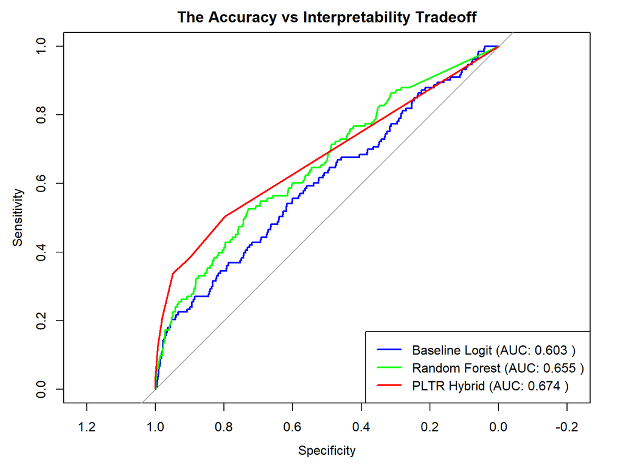

```r
actuals <- df_clean$Default
x_pltr <- as.matrix(cbind(df_clean[, base_vars], df_final[rownames(df_clean), grepl("_Node", colnames(df_final))]))

# Train Baseline Logit
baseline_model <- glm(Default ~ Liquidity + RetainedEarningsRatio + EBITRatio + MarketLeverage + AssetTurnover,
                      data = df_clean, family = "binomial")

# Train Random Forest
df_clean$Default_Factor <- as.factor(df_clean$Default)
set.seed(42)
rf_model <- randomForest(Default_Factor ~ Liquidity + RetainedEarningsRatio + EBITRatio + MarketLeverage + AssetTurnover,
                         data = df_clean, ntree = 500)

# Generate Predictions
prob_baseline <- predict(baseline_model, type = "response")
prob_rf <- predict(rf_model, type = "prob")[, "1"]
prob_pltr <- predict(adaptive_lasso, newx = x_pltr, s = "lambda.min", type = "response")

# ROC & AUC Calculation
roc_baseline <- roc(actuals, prob_baseline, quiet = TRUE)
roc_rf <- roc(actuals, prob_rf, quiet = TRUE)
roc_pltr <- roc(actuals, as.numeric(prob_pltr), quiet = TRUE)

# Brier Scores
brier_baseline <- mean((prob_baseline - actuals)^2)
brier_rf <- mean((prob_rf - actuals)^2)
brier_pltr <- mean((as.numeric(prob_pltr) - actuals)^2)

# Master Showdown Plot
plot(roc_baseline, col = "blue", main = "The Accuracy vs Interpretability Tradeoff", lwd = 2)
lines(roc_rf, col = "green", lwd = 2)
lines(roc_pltr, col = "red", lwd = 2)
legend("bottomright",
       legend = c(paste("Baseline Logit (AUC:", round(auc(roc_baseline), 3), ")"),
                  paste("Random Forest (AUC:", round(auc(roc_rf), 3), ")"),
                  paste("PLTR Hybrid (AUC:", round(auc(roc_pltr), 3), ")")),
       col = c("blue", "green", "red"), lwd = 2)
```

# Auditing the Black Box: The Final Scorecard

We achieved machine learning accuracy while preserving the interpretability required by regulators. Below are the top 10 most powerful risk multipliers (penalties) extracted by the Adaptive Lasso.

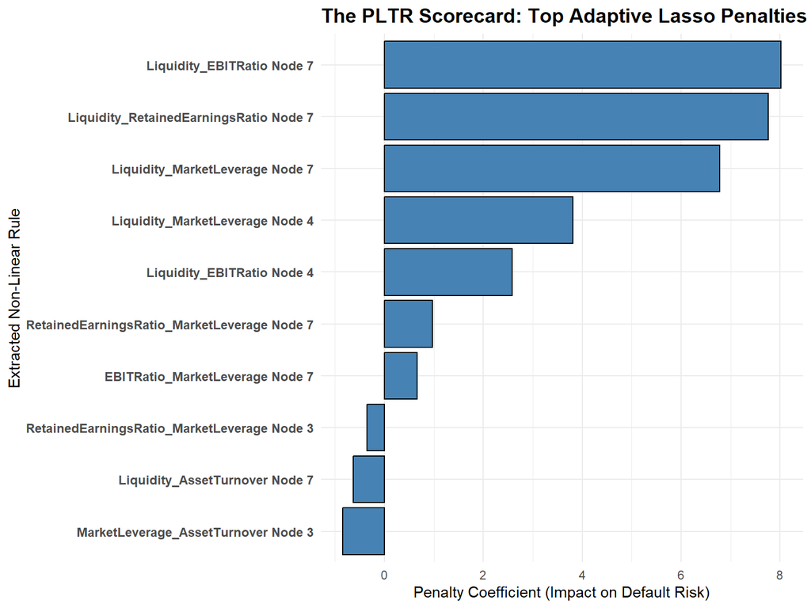

```r
# Isolate top non-linear rules surviving the Lasso penalty
top_rules <- surviving_vars %>%
  filter(Coefficient != 0 & grepl("_Node", Feature)) %>%
  arrange(desc(abs(Coefficient)))

# Visualizing the Top Penalties
chart_data <- head(top_rules, 10)
chart_data$Clean_Name <- gsub("_Nodeleaf_nodes", " Node ", chart_data$Feature)

ggplot(chart_data, aes(x = reorder(Clean_Name, Coefficient), y = Coefficient)) +
  geom_bar(stat = "identity", fill = "steelblue", color = "black") +
  coord_flip() +
  labs(title = "The PLTR Scorecard: Top Adaptive Lasso Penalties",
       x = "Extracted Non-Linear Rule",
       y = "Penalty Coefficient (Impact on Default Risk)") +
  theme_minimal() +
  theme(axis.text.y = element_text(size = 9, face = "bold"),
        plot.title = element_text(size = 14, face = "bold"))
```

## Unpacking the “Double Cut” Discovery

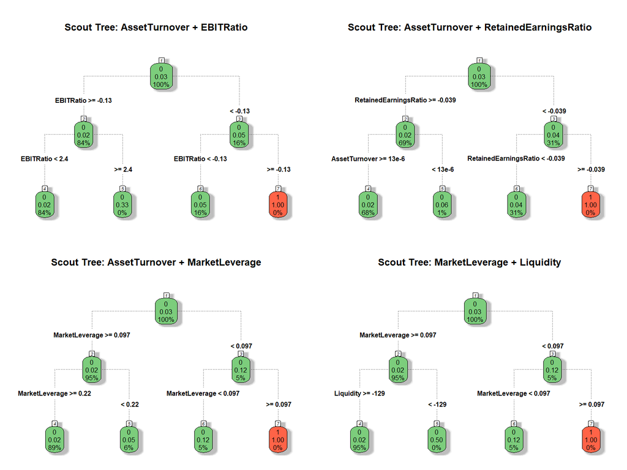

```r
tree_formulas <- list(
  "AssetTurnover + EBITRatio",
  "AssetTurnover + RetainedEarningsRatio",
  "AssetTurnover + MarketLeverage",
  "MarketLeverage + Liquidity"
)

par(mfrow = c(2, 2))
for (form in tree_formulas) {
  tree_model <- rpart(as.formula(paste("as.factor(Default) ~", form)),
                      data = df_clean, method = "class",
                      control = rpart.control(maxdepth = 2, cp = -1, minsplit = 2))

  rpart.plot(tree_model, type = 4, extra = 106,
             main = paste("Scout Tree:", form),
             box.palette = c("palegreen3", "tomato"),
             branch.lty = 3, shadow.col = "gray", nn = TRUE)
}
```

```r
par(mfrow = c(1, 1))
```